# Plateletes miRNA analysis

Data were processed with the nf-core small RNA-seq pipeline https://github.com/nf-core/smrnaseq which includes mirtop https://doi.org/10.1093/bioinformatics/btz675 to generate output in mirGFF3 format. Further analysis was performed using the R packages isoMiR, DEseq2 and ggplot2.

**Differential expression analysis overview:**

RPs vs MPs - CCS only - design = ~ patient + RPs.MPs (DE between RPs/MPs with paired patients) - data: 40 CCS samples - DE statistics for all genes: results/ccs_rp_vs_mp_diff_mir_counts.xlsx - only significant genes: results/ccs_rp_vs_mp_sign_diff_mir_counts.xlsx

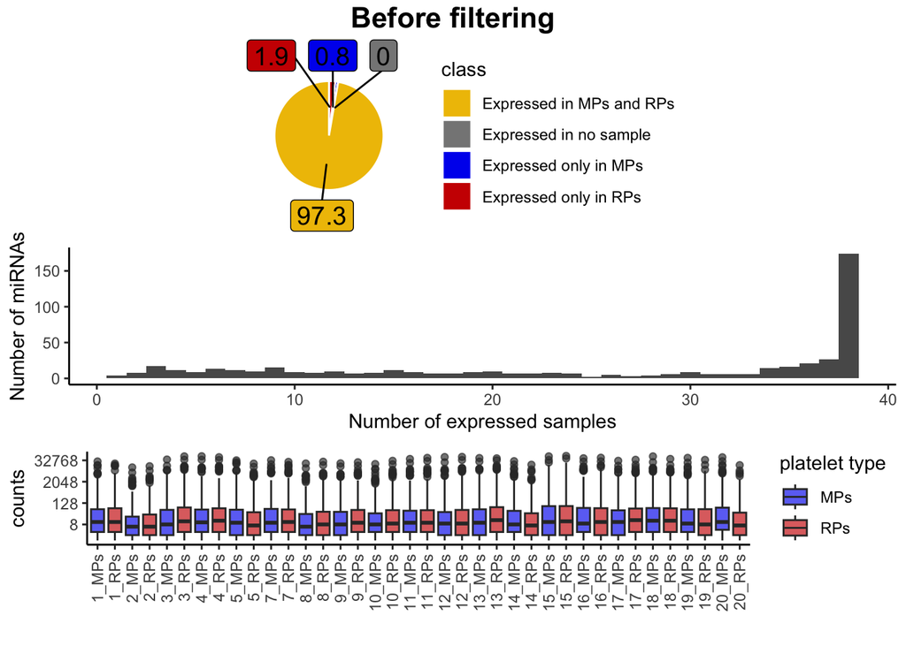

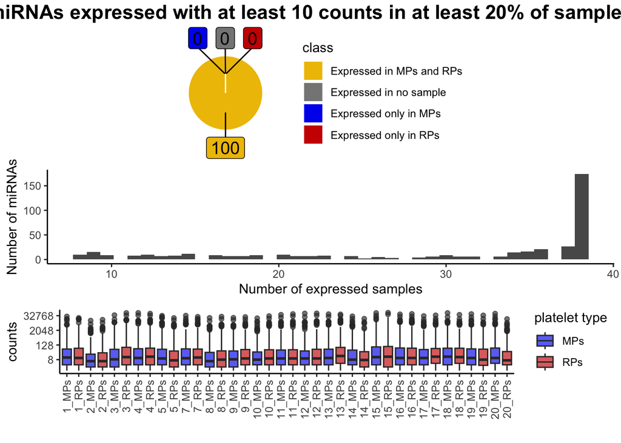

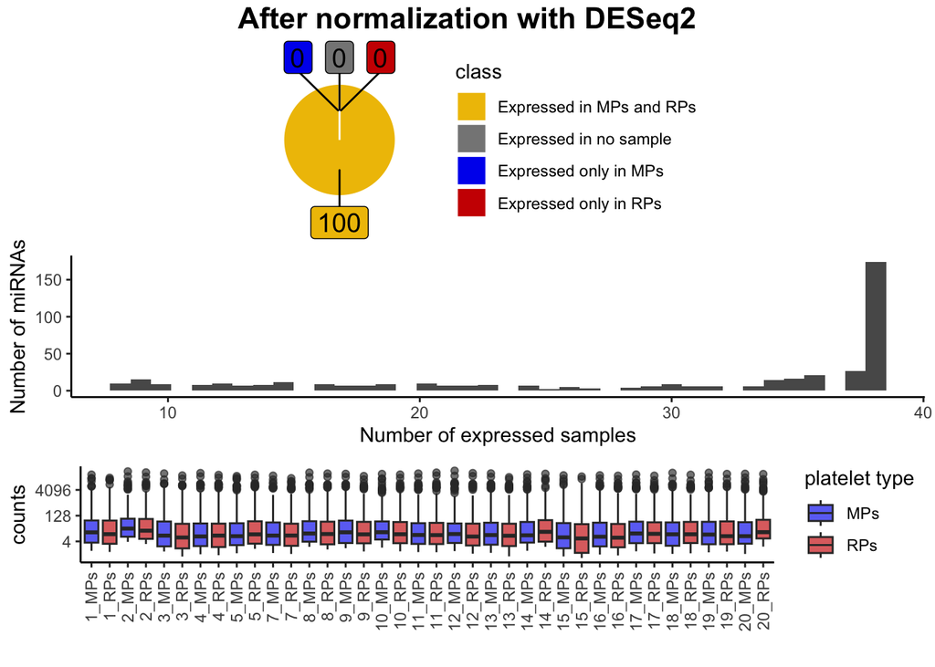

[figure not shown]

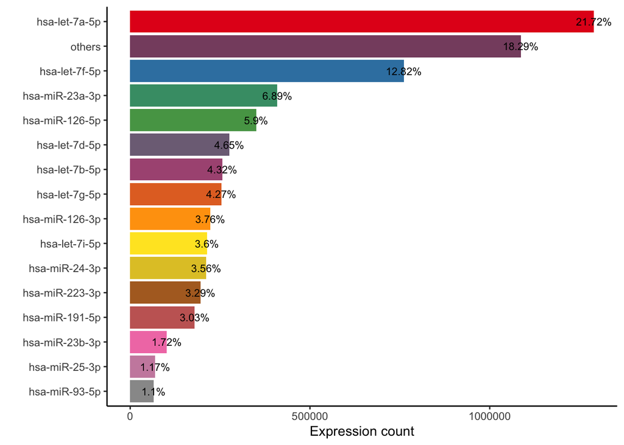

# RPs vs MPs - CCS only

Finally, we repeat the differential gene expression analysis for CCS patients only, as the sample quality is expected to be higher here.

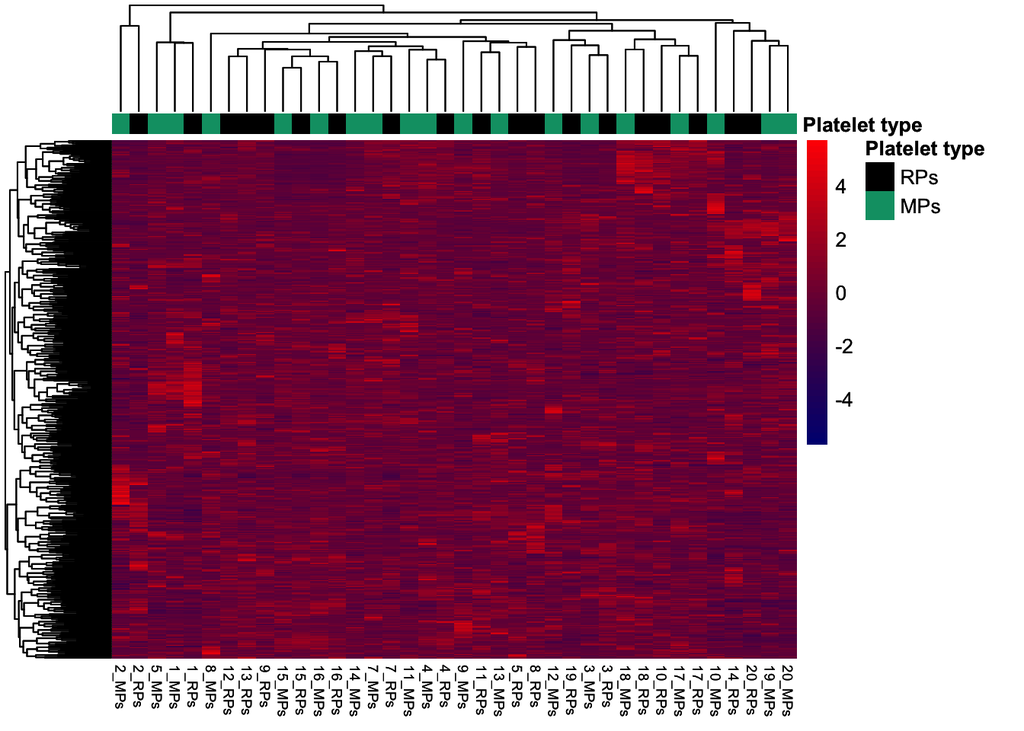

```r
dds_ccs_counts <- as.matrix(dds_ccs_counts)
plot <- pheatmap(dds_ccs_counts[which(rowVars(dds_ccs_counts) > 0.1),],
                 fontsize_col = 7,
                 color = colorRampPalette(c("navy", "red"))(50),
                 border_color = NA,
                 annotation_colors = list(`Platelet type` = c(RPs = cbbPalette[1], MPs = cbbPalette[4])),
                 annotation_col = metadata_ccs %>% dplyr::select(`Platelet type` = RPs_MPs),
                 show_rownames = FALSE,
                 show_colnames = TRUE,
                 scale="row")

png(paste0("plots/CCS_only_heatmap", version, ".png"), width = plot_width, height = plot_height, units = "in", res = plot_res)
plot
invisible(dev.off())
plot
```

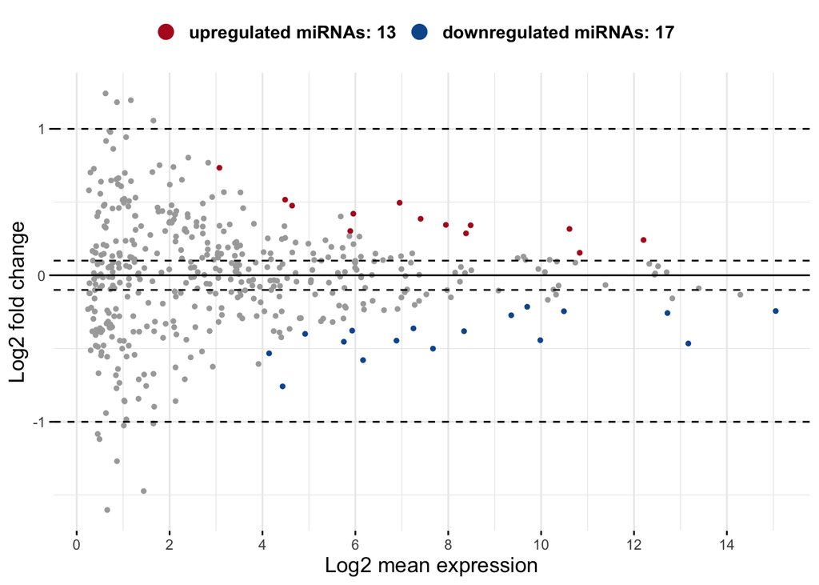

```r
plot <- myMAplot(dds_ccs_results, fdr = fdr, fc = FCcutoff)

png(paste0("plots/CCS_only_ma", version, ".png"), width = plot_width, height = plot_height, units = "in", res = plot_res)
plot
invisible(dev.off())
plot
```

PCA of CCS patients colored by MPs/RPs and labeled by sample:

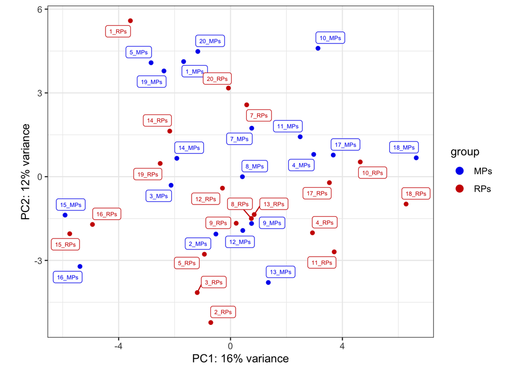

```r
plot <- myPCAplot(rlog(dds_ccs), intgroup = c("RPs_MPs")) +
          geom_label_repel(aes(label=sample_name), size = 2, show.legend = FALSE)

png(paste0("plots/CCS_only_pcs_RPvsMP", version, ".png"), width = plot_width, height = plot_height, units = "in", res = plot_res)
plot
invisible(dev.off())
plot
```

PCA of CCS patients colored by patient and labeled by MPs/RPs. The variance seems to be stronger between patients than between MPs/RPs.

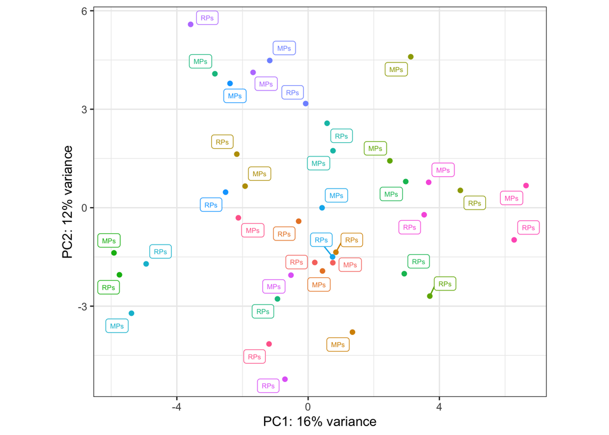

```r
plot <- myPCAplot(rlog(dds_ccs), intgroup = c("patient")) +
          geom_label_repel(aes(label=`RPs_MPs`), size = 2) + theme(legend.position="none")

png(paste0("plots/CCS_only_pca_patients", version, ".png"), width = plot_width, height = plot_height, units = "in", res = plot_res)
plot
invisible(dev.off())
plot
```

```r
#write.xlsx2(dds_ccs_results, paste0("results/ccs_rp_vs_mp_diff_mir_counts", version, ".xlsx"))
dds_ccs_sign_results <- dds_ccs_results %>%
  tibble::rownames_to_column() %>%
  filter(abs(log2FoldChange) > FCcutoff, padj < pCutoff) %>%
  arrange(padj)
#write.xlsx2(dds_ccs_sign_results, paste0("results/ccs_rp_vs_mp_sign_diff_mir_counts", version, ".xlsx"), row.names = F)
DT::datatable(dds_ccs_sign_results)
```

|  | rowname | baseMean | log2FoldChange | lfcSE | stat | pvalue | padj |
| --- | --- | --- | --- | --- | --- | --- | --- |
| 1 | hsa-miR-374a-5p | 20.60675074779486 | -0.7582312977978823 | 0.2230039566288292 | -3.400080022167018 | 0.0006736613484832851 | 0.01843382417213353 |
| 2 | hsa-miR-29a-3p | 21.4310601218516 | 0.5161179093742991 | 0.1575143042402351 | 3.276641520678241 | 0.001050496521480354 | 0.02564367080674475 |
| 3 | hsa-miR-128-3p | 7.414416226807401 | 0.7340472844937816 | 0.2498887774283942 | 2.937496001412562 | 0.003308744387462287 | 0.04966078947570088 |

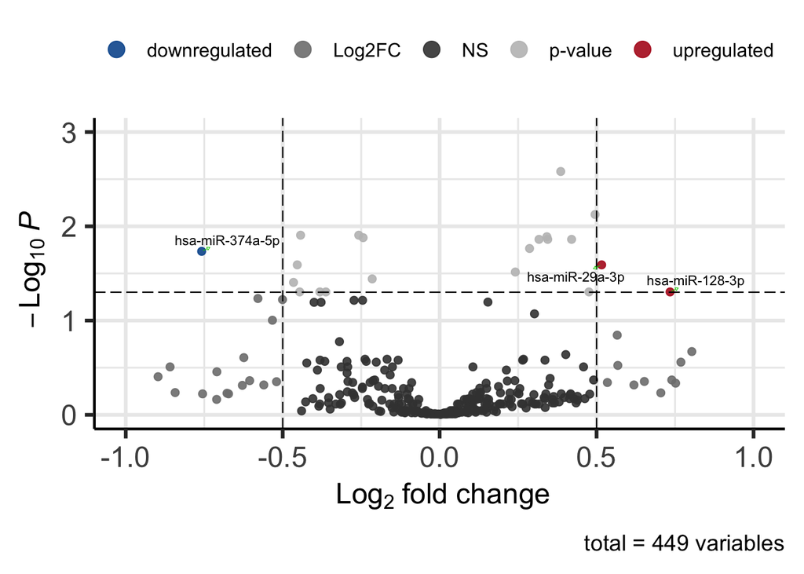

```r
plot <- myVolcanoPlot(dds_ccs_results,
                      data_type = "miRNA",
                      pCutoff = pCutoff,
                      FCcutoff = FCcutoff,
                      xlim = c(-1, 1),
                      ylim = c(0, 3))

png(paste0("plots/CCS_only_volcano", version, ".png"), width = plot_width, height = plot_height, units = "in", res = plot_res)
plot
invisible(dev.off())
plot
```